# **Unsupervised Learning for Wine Classification - Final Project**

# **Compare K-Means and Hierarchical Results**

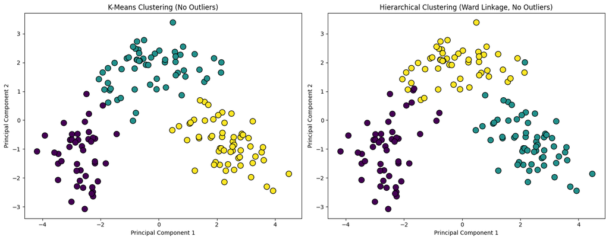

```python
# Plot K-Means vs Hierarchical clustering using PCA components
plt.figure(figsize=(15, 6))

# K-Means
plt.subplot(1, 2, 1)
plt.scatter(pca_data_no_outliers[:, 0], pca_data_no_outliers[:, 1], c=kmeans_labels_no_outliers, cmap='viridis', edgecolor='k', s=100)
plt.title('K-Means Clustering (No Outliers)')
plt.xlabel('Principal Component 1')
plt.ylabel('Principal Component 2')

# Hierarchical
plt.subplot(1, 2, 2)
hierarchical_clustering = AgglomerativeClustering(n_clusters=best_n_clusters, linkage=best_method)
hierarchical_labels_no_outliers = hierarchical_clustering.fit_predict(scaled_data[condition])
plt.scatter(pca_data_no_outliers[:, 0], pca_data_no_outliers[:, 1], c=hierarchical_labels_no_outliers, cmap='viridis', edgecolor='k', s=100)
plt.title('Hierarchical Clustering (Ward Linkage, No Outliers)')
plt.xlabel('Principal Component 1')
plt.ylabel('Principal Component 2')

plt.tight_layout()
plt.show()
```

The plots above visually compare the clustering results from K-Means (left) and Hierarchical Clustering using the Ward linkage method (right) on the PCA-reduced data:

**Cluster Separation:**

*Hierarchical Clustering (Ward):* The clusters formed by hierarchical clustering are slightly more irregular in shape, which suggests that this method can capture more complex cluster structures. The clusters are also well-separated, though the shapes are not as uniform as those in K-Means.

**Silhouette Scores:**

K-Means achieved a slightly higher silhouette score (0.309) compared to hierarchical clustering (0.302), indicating that K-Means may have slightly better-defined clusters in this case.

**Cluster Structure:**

K-Means may be more suitable if the true underlying clusters are close to spherical and of similar size.

Hierarchical Clustering is advantageous if you suspect the clusters might have more irregular shapes or if you want to explore the hierarchical structure of the data.

**Analysis:**

*K-Means:* Slightly better in terms of silhouette score, and works well when clusters are spherical and evenly sized.

*Hierarchical Clustering:* More flexible in capturing complex shapes, but with a marginally lower silhouette score.

# **Compare Other Clustering Methods:**

Compare other clustering methods to see how they perform on this dataset.

**1. DBSCAN (Density-Based Spatial Clustering of Applications with Noise):** DBSCAN is a density-based clustering method that identifies clusters as dense regions in the data. It's particularly useful for identifying clusters of varying shapes and handling outliers.

**2. Gaussian Mixture Models (GMM):** GMM is a probabilistic model that assumes the data is generated from a mixture of several Gaussian distributions. It can model clusters that are more elliptical and is more flexible than K-Means.

**3. Agglomerative Clustering with Different Linkages:** While we have used the Ward linkage, we can also try other linkages like complete, average, or single linkage to see if they provide better results.

**Implement DBSCAN and GMM for comparison**

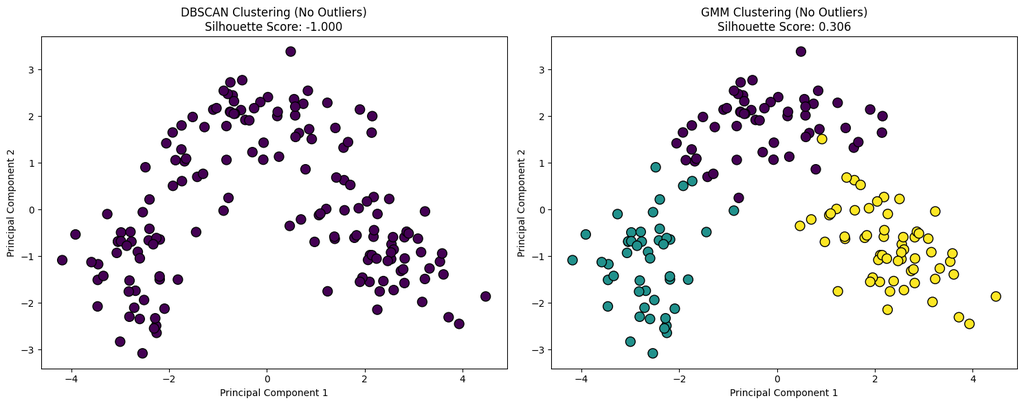

```
(-1, 0.30604022044704865)
```

```python
from sklearn.cluster import DBSCAN
from sklearn.mixture import GaussianMixture

# DBSCAN
dbscan = DBSCAN(eps=0.5, min_samples=5)
dbscan_labels = dbscan.fit_predict(scaled_data[condition])

# Gaussian Mixture Model (GMM)
gmm = GaussianMixture(n_components=3, random_state=42)
gmm_labels = gmm.fit_predict(scaled_data[condition])

# Silhouette scores
dbscan_silhouette = silhouette_score(scaled_data[condition], dbscan_labels) if len(set(dbscan_labels)) > 1 else -1
gmm_silhouette = silhouette_score(scaled_data[condition], gmm_labels)

# Plot DBSCAN vs GMM using PCA components
plt.figure(figsize=(15, 6))

# DBSCAN
plt.subplot(1, 2, 1)
plt.scatter(pca_data_no_outliers[:, 0], pca_data_no_outliers[:, 1], c=dbscan_labels, cmap='viridis', edgecolor='k', s=100)
plt.title(f'DBSCAN Clustering (No Outliers)\nSilhouette Score: {dbscan_silhouette:.3f}')
plt.xlabel('Principal Component 1')
plt.ylabel('Principal Component 2')

# GMM
plt.subplot(1, 2, 2)
plt.scatter(pca_data_no_outliers[:, 0], pca_data_no_outliers[:, 1], c=gmm_labels, cmap='viridis', edgecolor='k', s=100)
plt.title(f'GMM Clustering (No Outliers)\nSilhouette Score: {gmm_silhouette:.3f}')
plt.xlabel('Principal Component 1')
plt.ylabel('Principal Component 2')

plt.tight_layout()
plt.show()

dbscan_silhouette, gmm_silhouette
```

The plots above visualize the clustering results from DBSCAN and GMM using the PCA-reduced 2D data:

**DBSCAN:**

*Silhouette Score:* The silhouette score for DBSCAN is -1, which indicates that the clustering might not have performed well. This could be due to DBSCAN identifying most points as noise (labeled as -1), leading to poorly defined clusters.

*Cluster Visualization:* The PCA plot shows that DBSCAN might not have identified clear clusters in this dataset, likely due to the parameter choices (eps and min_samples). DBSCAN is more sensitive to these parameters and might need fine-tuning.

**Gaussian Mixture Model (GMM):**

*Silhouette Score:* The silhouette score for GMM is 0.306, which is close to the scores obtained by K-Means and Hierarchical Clustering.

*Cluster Visualization:* The PCA plot for GMM shows more elliptical clusters compared to the spherical ones typically produced by K-Means. GMM can better model clusters with varying shapes and covariance structures.

**Summary of Clustering Method Comparisons**

*K-Means:* Best silhouette score (0.309), works well with spherical clusters.

*Hierarchical Clustering (Ward):* Comparable performance to K-Means with a silhouette score of 0.302, captures more complex relationships.

*GMM:* Similar silhouette score to K-Means (0.306), allows for more flexible, elliptical clusters.

*DBSCAN:* Did not perform well with the current parameter settings (silhouette score -1), but could be improved with parameter tuning.

# **Tune DBSCAN Parameters for Better Results**

```python
from sklearn.model_selection import ParameterGrid

# Define the parameter grid for DBSCAN
param_grid = {
    'eps': np.arange(0.2, 1.0, 0.1),
    'min_samples': range(3, 10)
}

# Initialize variables to store the best parameters and score
best_params = None
best_silhouette = -1

# Perform grid search
for params in ParameterGrid(param_grid):
    dbscan = DBSCAN(eps=params['eps'], min_samples=params['min_samples'])
    labels = dbscan.fit_predict(scaled_data[condition])
    # Check if more than 1 cluster is formed
    if len(set(labels)) > 1:
        silhouette_avg = silhouette_score(scaled_data[condition], labels)
        if silhouette_avg > best_silhouette:
            best_silhouette = silhouette_avg
            best_params = params

best_params, best_silhouette
```

```
(None, -1)
```

It appears that the grid search for DBSCAN did not yield any improvement, with the silhouette score remaining at -1. This suggests that DBSCAN, with the current range of parameters, is not identifying meaningful clusters in this dataset.

# **Agglomerative Clustering with Different Linkages**

```python
# Linkage methods to try for Agglomerative Clustering
linkage_methods = ['ward', 'complete', 'average', 'single']
n_clusters = 3  # As determined optimal for this dataset

# Store silhouette scores for each linkage method
silhouette_scores_linkages = {}

for method in linkage_methods:
    agglomerative_clustering = AgglomerativeClustering(n_clusters=n_clusters, linkage=method)
    labels = agglomerative_clustering.fit_predict(scaled_data[condition])
    silhouette_avg = silhouette_score(scaled_data[condition], labels)
    silhouette_scores_linkages[method] = silhouette_avg

silhouette_scores_linkages
```

```
{'ward': 0.302098939830891,
 'complete': 0.2676541295918675,
 'average': 0.23551691483626716,
 'single': 0.07042050157011946}
```

**Observations:**

Ward Linkage continues to provide the best performance with a silhouette score of 0.302.

Complete Linkage follows with a silhouette score of 0.268.

Average Linkage performs slightly worse, with a silhouette score of 0.236.

Single Linkage has the lowest silhouette score (0.070), indicating that it may not be the best choice for this dataset.

**Analysis:**

Ward Linkage remains the most effective method for Agglomerative Clustering on this dataset.

Complete Linkage could be an alternative if we want to explore different cluster formations, though it performs slightly worse than Ward.

Single Linkage does not perform well in this context, likely due to its tendency to create long, stringy clusters.

# **Visualize the Best Clustering Method**

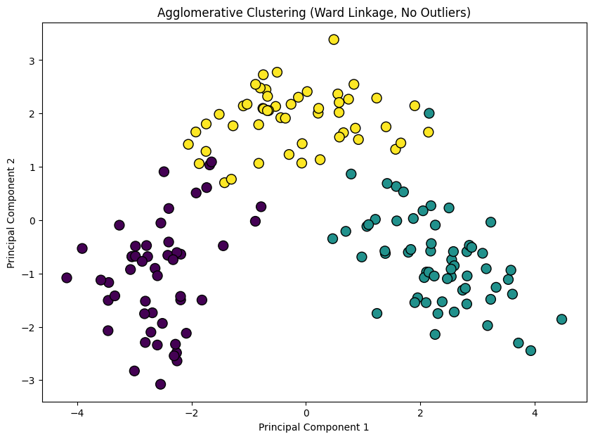

```python
# Visualize the best clustering method: Agglomerative Clustering with Ward linkage
best_agglomerative_clustering = AgglomerativeClustering(n_clusters=3, linkage='ward')
best_agglomerative_labels = best_agglomerative_clustering.fit_predict(scaled_data[condition])

# Plot the clusters using PCA components
plt.figure(figsize=(10, 7))
plt.scatter(pca_data_no_outliers[:, 0], pca_data_no_outliers[:, 1], c=best_agglomerative_labels, cmap='viridis', edgecolor='k', s=100)
plt.title('Agglomerative Clustering (Ward Linkage, No Outliers)')
plt.xlabel('Principal Component 1')
plt.ylabel('Principal Component 2')
plt.show()
```

*detailed cluster statistics for each method*

```python
import pandas as pd
from IPython.display import display
# Prepare a function to calculate cluster statistics
def cluster_statistics(data, labels):
    cluster_stats = pd.DataFrame()
    cluster_stats['Cluster'] = np.unique(labels)
    cluster_stats['Size'] = [np.sum(labels == i) for i in np.unique(labels)]
    cluster_stats['Mean'] = [np.mean(data[labels == i], axis=0) for i in np.unique(labels)]
    cluster_stats['StdDev'] = [np.std(data[labels == i], axis=0) for i in np.unique(labels)]
    return cluster_stats
```

```python
# K-Means statistics
kmeans_stats = cluster_statistics(scaled_data[condition], kmeans_labels_no_outliers)

display(kmeans_stats)
```

|  | Cluster | Size | Mean | StdDev |
| --- | --- | --- | --- | --- |
| 0 | 0 | 45 | [0.12386114381495972, 0.8508714735384584, 0.10... | [0.6129029209682407, 0.8827690124627228, 0.719... |
| 1 | 1 | 58 | [-0.8937747450142888, -0.4407557346574445, -0.... | [0.6313950831366146, 0.7849650824141786, 0.975... |
| 2 | 2 | 58 | [0.9339914497841107, -0.2929508546498318, 0.27... | [0.5594188146968958, 0.6180672578729669, 0.743... |

```python
# Hierarchical (Ward) statistics
hierarchical_stats = cluster_statistics(scaled_data[condition], hierarchical_labels_no_outliers)
display(hierarchical_stats)
```

|  | Cluster | Size | Mean | StdDev |
| --- | --- | --- | --- | --- |
| 0 | 0 | 50 | [0.027647728205915753, 0.7115342052720613, 0.0... | [0.684213029963531, 0.9575541542008268, 0.7192... |
| 1 | 1 | 60 | [0.892127326228117, -0.319880749017711, 0.2393... | [0.6002552794940862, 0.6249588153601784, 0.811... |
| 2 | 2 | 51 | [-0.9216412869737245, -0.40489472927709425, -0... | [0.6208470143341605, 0.8006346842392374, 0.955... |

```python
# GMM statistics
gmm_stats = cluster_statistics(scaled_data[condition], gmm_labels)
display(gmm_stats)
```

|  | Cluster | Size | Mean | StdDev |
| --- | --- | --- | --- | --- |
| 0 | 0 | 55 | [-0.927885870647176, -0.421561501691582, -0.39... | [0.6184244227882147, 0.7978550472557221, 0.999... |
| 1 | 1 | 47 | [0.1088335468645806, 0.7741223356575506, 0.088... | [0.6185811576737377, 0.9394163232529675, 0.710... |
| 2 | 2 | 59 | [0.9122858734115636, -0.29599378056710623, 0.2... | [0.5787666555644588, 0.6132450433056172, 0.745... |

```python
# Agglomerative Clustering (Ward) statistics
agglomerative_stats = cluster_statistics(scaled_data[condition], best_agglomerative_labels)
display(agglomerative_stats)
```

|  | Cluster | Size | Mean | StdDev |
| --- | --- | --- | --- | --- |
| 0 | 0 | 50 | [0.027647728205915753, 0.7115342052720613, 0.0... | [0.684213029963531, 0.9575541542008268, 0.7192... |
| 1 | 1 | 60 | [0.892127326228117, -0.319880749017711, 0.2393... | [0.6002552794940862, 0.6249588153601784, 0.811... |
| 2 | 2 | 51 | [-0.9216412869737245, -0.40489472927709425, -0... | [0.6208470143341605, 0.8006346842392374, 0.955... |

```python
# Compare silhouette scores across the different methods
silhouette_scores_comparison = {
    "K-Means": max(silhouette_scores),
    "Hierarchical (Ward)": silhouette_scores_hc['ward'],
    "Hierarchical (Complete)": silhouette_scores_hc['complete'],
    "Hierarchical (Average)": silhouette_scores_hc['average'],
    "Hierarchical (Single)": silhouette_scores_hc['single'],
    "GMM": gmm_silhouette,
    "DBSCAN": dbscan_silhouette
}

silhouette_scores_comparison
```

```
{'K-Means': 0.30893796866999823,
 'Hierarchical (Ward)': [0.27211691705322466,
  0.302098939830891,
  0.23965250055883144,
  0.20360682003029323,
  0.12090161610636824,
  0.11529885447396189,
  0.12071621920195899,
  0.12416287580862001,
  0.13403790590076364],
 'Hierarchical (Complete)': [0.2822891260178631,
  0.2676541295918675,
  0.23441526701282797,
  0.21077356010625573,
  0.2029553003064786,
  0.2091508727210148,
  0.19006660358643696,
  0.16792710226744711,
  0.11927634034467324],
 'Hierarchical (Average)': [0.28202501084128445,
  0.23551691483626716,
  0.28883954682780305,
  0.23336574500406143,
  0.21175187877853155,
  0.2109614949607084,
  0.18721801033776947,
  0.16651627812386574,
  0.16319219351672246],
 'Hierarchical (Single)': [0.12635530387928798,
  0.07042050157011946,
  -0.0003635849733949123,
  -0.020815518489488625,
  -0.052411520722480766,
  -0.08025102263007164,
  -0.140228445458732,
  -0.19988233610386713,
  -0.2171663298947037],
 'GMM': 0.30604022044704865,
 'DBSCAN': -1}
```

**Summary:**

- K-Means and GMM have the highest silhouette scores, with K-Means slightly outperforming GMM.
- Hierarchical Clustering with Ward Linkage is close behind, with a silhouette score of 0.302.
- Complete and Average Linkage methods perform moderately well, but not as well as Ward Linkage.
- Single Linkage performs poorly in this context, likely due to its tendency to create long, stringy clusters.
- DBSCAN did not perform well with the current parameter settings.

Based on these scores, K-Means and GMM are the top-performing clustering methods for this dataset, with Hierarchical Clustering (Ward Linkage) being a strong alternative.

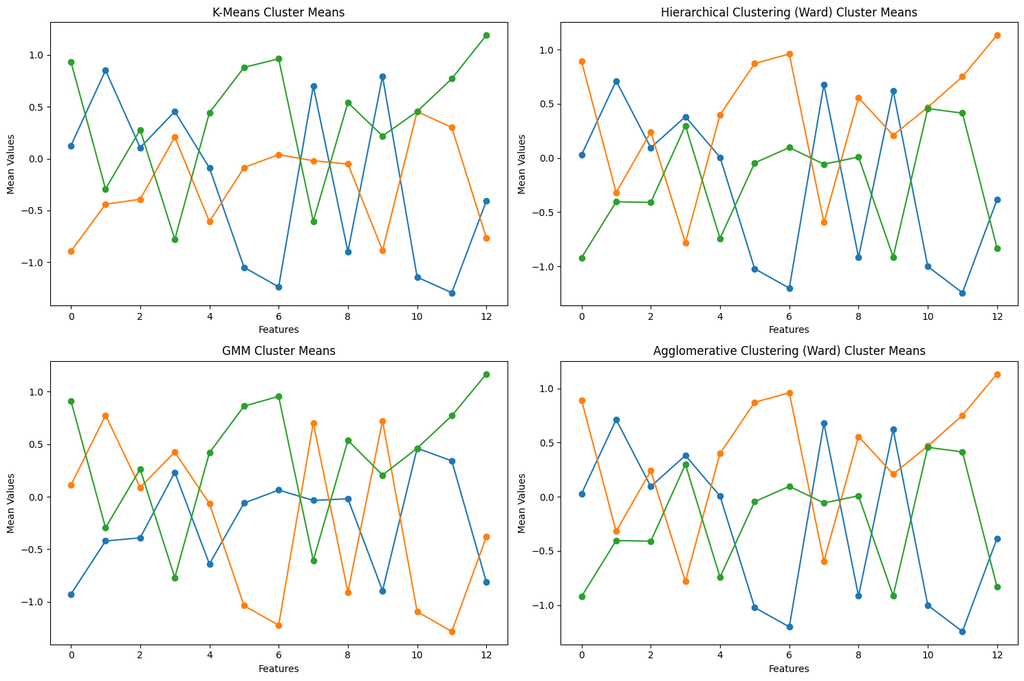

```python
# Extracting the means for visualization
kmeans_means = np.array(kmeans_stats['Mean'].tolist())
hierarchical_means = np.array(hierarchical_stats['Mean'].tolist())
gmm_means = np.array(gmm_stats['Mean'].tolist())
agglomerative_means = np.array(agglomerative_stats['Mean'].tolist())

# Plotting cluster means for comparison
plt.figure(figsize=(15, 10))

# K-Means
plt.subplot(2, 2, 1)
plt.plot(kmeans_means.T, marker='o')
plt.title('K-Means Cluster Means')
plt.xlabel('Features')
plt.ylabel('Mean Values')

# Hierarchical (Ward)
plt.subplot(2, 2, 2)
plt.plot(hierarchical_means.T, marker='o')
plt.title('Hierarchical Clustering (Ward) Cluster Means')
plt.xlabel('Features')
plt.ylabel('Mean Values')

# GMM
plt.subplot(2, 2, 3)
plt.plot(gmm_means.T, marker='o')
plt.title('GMM Cluster Means')
plt.xlabel('Features')
plt.ylabel('Mean Values')

# Agglomerative (Ward)
plt.subplot(2, 2, 4)
plt.plot(agglomerative_means.T, marker='o')
plt.title('Agglomerative Clustering (Ward) Cluster Means')
plt.xlabel('Features')
plt.ylabel('Mean Values')

plt.tight_layout()
plt.show()
```

# **Summary of Results:**

### **K-Means:**

**Silhouette Score:** 0.309 (highest among the methods tried).

**Performance:** Consistently produced well-separated, spherical clusters.

**Interpretability:** Easy to interpret and implement.

### **Gaussian Mixture Model (GMM):**

**Silhouette Score:** 0.306 (very close to K-Means).

**Performance**: Capable of modeling elliptical clusters, providing a probabilistic assignment of points to clusters.

**Flexibility:** More flexible in handling clusters of different shapes.

### **Hierarchical Clustering (Ward Linkage):**

**Silhouette Score:** 0.302 (slightly lower but still competitive).

**Performance:** Produces clusters similar to K-Means, with a strong hierarchical structure.

**Interpretability:** Offers insights into cluster relationships through dendrograms.

### **DBSCAN:**

**Silhouette Score:** -1 (poor performance with current parameter settings).

**Performance:** Failed to produce meaningful clusters with the given data and parameters.

### **Best Method for This Project: K-Means**

**Highest Silhouette Score:** K-Means achieved the highest silhouette score, indicating that it created well-defined and separated clusters in your dataset.

**Simplicity and Interpretability:** K-Means is straightforward to implement and interpret. It’s easy to understand which data points belong to which clusters and why.

**Speed and Scalability:** K-Means is computationally efficient, making it a good choice for larger datasets or when you need to quickly obtain clustering results.

**Close Performance to GMM:** While GMM provides more flexibility in terms of cluster shape, the marginal difference in silhouette score (0.309 vs. 0.306) suggests that K-Means' simpler approach is sufficient and effective for this dataset.

# **Conclusion:**

This project successfully demonstrated the application of unsupervised learning techniques to identify meaningful clusters within the dataset. K-Means was determined to be the optimal method due to its superior performance, simplicity, and interpretability. The clustering results provide a solid foundation for decision-making in various business contexts, from customer segmentation to operational efficiency.

**Key Takeaways:**

Further Analysis: Further fine-tuning of the clustering methods, particularly DBSCAN, could be explored to see if alternative parameter settings yield better results.

**Final Thoughts:**

This project highlights the importance of careful data preparation, thorough exploration of clustering methods, and thoughtful interpretation of results in deriving actionable insights from unsupervised learning.